# Regressions Model Final Project

## Introduction

Thanks for tuning in for this month’s edition of Motor Trends magazine! In this issue, we’ll be focusing in on the relationship between the type of transmision a vehicle has and the associated miles per gallon. Overall, we will want to answer two questions:

“Is an automatic or manual transmission better for MPG?” “Quantify the MPG difference between automatic and manual transmissions?”

## Exploratory Analysis

First, let’s take a look at the data to understand what we’re dealing with.

```r
head(mtcars)
summary(mtcars)
```

[output not shown]

It looks like the transmission variable (am) is not being treated as a factor; let’s change that! Then lets look at the correlation between the transmission and mpg.

```r
mtcars$am <- as.factor(mtcars$am)
```

```r
summary(lm(mpg ~ ., data=mtcars))
```

[output not shown]

```r
summary(lm(mtcars$mpg ~ mtcars$am))
```

```
##
## Call:
## lm(formula = mtcars$mpg ~ mtcars$am)
##
## Residuals:
##     Min      1Q  Median      3Q     Max
## -9.3923 -3.0923 -0.2974  3.2439  9.5077
##
## Coefficients:
##             Estimate Std. Error t value Pr(>|t|)
## (Intercept)   17.147      1.125  15.247 1.13e-15 ***
## mtcars$am1     7.245      1.764   4.106 0.000285 ***
## ---
## Signif. codes:  0 '***' 0.001 '**' 0.01 '*' 0.05 '.' 0.1 ' ' 1
##
## Residual standard error: 4.902 on 30 degrees of freedom
## Multiple R-squared:  0.3598, Adjusted R-squared:  0.3385
## F-statistic: 16.86 on 1 and 30 DF,  p-value: 0.000285
```

While the correlation looks statistically significant at first, let’s plot the mtcars data set. Given that many people’s first inclination is that heavier cars tend to weigh more, I will plot miles per gallon vs weight, while coloring the data with the transmission factor.

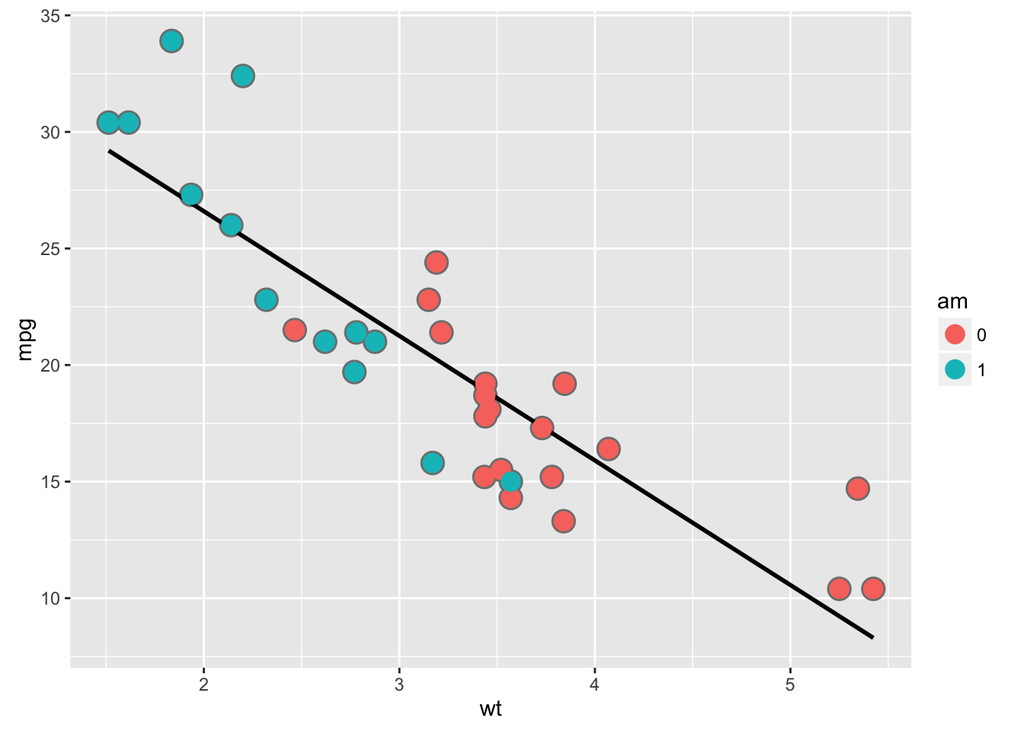

```r
library(ggplot2)
g=ggplot(mtcars, aes(y=mpg, x=wt, colour=am))
g= g + geom_point(colour = "grey50", size=5) + geom_smooth(method = lm, se = FALSE, colour= "black") + geom_point(size=4)
g
```

From this plot, it looks like manual transmissions do have higher miles per gallon, but it also looks like the manual vehicles tend to weigh less as well. For this reason, we must look at other variables as well for this analysis.

In the appendix, you can see the various linear models we put together; however, the linear model below shows the variables with the most statistical significance for multiple variables.

```r
summary(lm(mtcars$mpg ~ mtcars$am+mtcars$wt+mtcars$hp))
```

```
##
## Call:
## lm(formula = mtcars$mpg ~ mtcars$am + mtcars$wt + mtcars$hp)
##
## Residuals:
##     Min      1Q  Median      3Q     Max
## -3.4221 -1.7924 -0.3788  1.2249  5.5317
##
## Coefficients:
##              Estimate Std. Error t value Pr(>|t|)
## (Intercept) 34.002875   2.642659  12.867 2.82e-13 ***
## mtcars$am1   2.083710   1.376420   1.514 0.141268
## mtcars$wt   -2.878575   0.904971  -3.181 0.003574 **
## mtcars$hp   -0.037479   0.009605  -3.902 0.000546 ***
## ---
## Signif. codes:  0 '***' 0.001 '**' 0.01 '*' 0.05 '.' 0.1 ' ' 1
##
## Residual standard error: 2.538 on 28 degrees of freedom
## Multiple R-squared:  0.8399, Adjusted R-squared:  0.8227
## F-statistic: 48.96 on 3 and 28 DF,  p-value: 2.908e-11
```

## Conclusion

Based on the analysis, we cannot say that an automatic or manual transmission has a significant effect on the miles per gallon. Rather, we should be looking at other variables such as weight and horsepower to answer this question.

Knowing that weight was a significant varable, we looked at linear models for other variables as well, to see if we could find models with other statistically significant variables.

The two models with the highest R Squared values were those with:

1. am, wt, cyl, and hp
2. am, wt, hp

However, given that the R-Squared values were very similar for the two, I chose the second model since both weight and horsepower had statistically significant values.

```
##
## Call:
## lm(formula = mtcars$mpg ~ mtcars$am + mtcars$wt)
##
## Residuals:
##     Min      1Q  Median      3Q     Max
## -4.5295 -2.3619 -0.1317  1.4025  6.8782
##
## Coefficients:
##             Estimate Std. Error t value Pr(>|t|)
## (Intercept) 37.32155    3.05464  12.218 5.84e-13 ***
## mtcars$am1  -0.02362    1.54565  -0.015    0.988
## mtcars$wt   -5.35281    0.78824  -6.791 1.87e-07 ***
## ---
## Signif. codes:  0 '***' 0.001 '**' 0.01 '*' 0.05 '.' 0.1 ' ' 1
##
## Residual standard error: 3.098 on 29 degrees of freedom
## Multiple R-squared:  0.7528, Adjusted R-squared:  0.7358
## F-statistic: 44.17 on 2 and 29 DF,  p-value: 1.579e-09
```

```
##
## Call:
## lm(formula = mtcars$mpg ~ mtcars$am + mtcars$wt + mtcars$cyl)
##
## Residuals:
##     Min      1Q  Median      3Q     Max
## -4.1735 -1.5340 -0.5386  1.5864  6.0812
##
## Coefficients:
##             Estimate Std. Error t value Pr(>|t|)
## (Intercept)  39.4179     2.6415  14.923 7.42e-15 ***
## mtcars$am1    0.1765     1.3045   0.135  0.89334
## mtcars$wt    -3.1251     0.9109  -3.431  0.00189 **
## mtcars$cyl   -1.5102     0.4223  -3.576  0.00129 **
## ---
## Signif. codes:  0 '***' 0.001 '**' 0.01 '*' 0.05 '.' 0.1 ' ' 1
##
## Residual standard error: 2.612 on 28 degrees of freedom
## Multiple R-squared:  0.8303, Adjusted R-squared:  0.8122
## F-statistic: 45.68 on 3 and 28 DF,  p-value: 6.51e-11
```

```
##
## Call:
## lm(formula = mtcars$mpg ~ mtcars$am + mtcars$wt + mtcars$hp)
##
## Residuals:
##     Min      1Q  Median      3Q     Max
## -3.4221 -1.7924 -0.3788  1.2249  5.5317
##
## Coefficients:
##              Estimate Std. Error t value Pr(>|t|)
## (Intercept) 34.002875   2.642659  12.867 2.82e-13 ***
## mtcars$am1   2.083710   1.376420   1.514 0.141268
## mtcars$wt   -2.878575   0.904971  -3.181 0.003574 **
## mtcars$hp   -0.037479   0.009605  -3.902 0.000546 ***
## ---
## Signif. codes:  0 '***' 0.001 '**' 0.01 '*' 0.05 '.' 0.1 ' ' 1
##
## Residual standard error: 2.538 on 28 degrees of freedom
## Multiple R-squared:  0.8399, Adjusted R-squared:  0.8227
## F-statistic: 48.96 on 3 and 28 DF,  p-value: 2.908e-11
```

```
##
## Call:
## lm(formula = mtcars$mpg ~ mtcars$am + mtcars$wt + mtcars$cyl +
##     mtcars$hp)
##
## Residuals:
##     Min      1Q  Median      3Q     Max
## -3.4765 -1.8471 -0.5544  1.2758  5.6608
##
## Coefficients:
##             Estimate Std. Error t value Pr(>|t|)
## (Intercept) 36.14654    3.10478  11.642 4.94e-12 ***
## mtcars$am1   1.47805    1.44115   1.026   0.3142
## mtcars$wt   -2.60648    0.91984  -2.834   0.0086 **
## mtcars$cyl  -0.74516    0.58279  -1.279   0.2119
## mtcars$hp   -0.02495    0.01365  -1.828   0.0786 .
## ---
## Signif. codes:  0 '***' 0.001 '**' 0.01 '*' 0.05 '.' 0.1 ' ' 1
##
## Residual standard error: 2.509 on 27 degrees of freedom
## Multiple R-squared:  0.849,  Adjusted R-squared:  0.8267
## F-statistic: 37.96 on 4 and 27 DF,  p-value: 1.025e-10
```